# Modelling canine rabies dynamics in Arequipa, Peru

Brinkley Raynor

## Methods

All work has been done in R using the code contained in this R markdown file.

```r
#Load libaries
suppressMessages(suppressWarnings(library(deSolve)))
suppressMessages(suppressWarnings(library(ggplot2)))
suppressMessages(suppressWarnings(library(dplyr)))
suppressMessages(suppressWarnings(library(stringr)))
suppressMessages(suppressWarnings(library(rgdal)))
suppressMessages(suppressWarnings(library(MASS)))
suppressMessages(suppressWarnings(library(leaflet)))
```

#### Data

Data files will not be made publically available as they contain confidential information. The original files are accessible in the Castillo lab “Rabies” github repository. We will use two sources of data: 1. Rabies case reports 2. Longitudinal survey data

Rabies case reports come from collaboration from the Ministry of Health and from notes from the Zoonotic Disease Research Lab.

```r
#Load rabies case data
df      <- read.csv("~/Rabies/models/Data/RabiesCaseData_7May2020.csv")  #Rabies case reports

#clean and format the case data
df <- df %>%
  rename(LabID = ï..LabID) %>%
  mutate(
    Symptoms_date         = as.Date(Symptoms_date,         "%d/%m/%Y"),
    Complaint_date        = as.Date(Complaint_date,        "%d/%m/%Y"),
    Death_date            = as.Date(Death_date,            "%d/%m/%Y"),
    Obtained_date         = as.Date(Obtained_date,         "%d/%m/%Y"),
    Received_date         = as.Date(Received_date,         "%d/%m/%Y"),
    Result_date           = as.Date(Result_date,           "%d/%m/%Y"),
    ContainmentStart_date = as.Date(ContainmentStart_date, "%d/%m/%Y"),
    ContainmentOther_date = as.Date(ContainmentOther_date, "%d/%m/%Y"),
    MedicalAttention_date = as.Date(MedicalAttention_date, "%d/%m/%Y"),
    DateCaseBitten        = as.Date(DateCaseBitten,        "%d/%m/%Y"),
    NumDogsCaseBit        = as.numeric(as.character(NumDogsCaseBit)),
    Month                 = as.numeric(as.character(Month)), #Format as number
    Years                 = as.numeric(as.character(Years)), #Format as number
    Age                   = Years*365.25 + Month*30.4375     #Calculate age in days
  )
#Add on year labels
df$year <- 2020
df$year[1:19] <- 2015
df$year[20:79] <- 2016
df$year[80:129] <- 2017
df$year[130:165] <- 2018
df$year[166:204] <- 2019

#Read in the incidence table
rabies  <- read.csv("~/Rabies/models/Data/Rabies_IncidenceTable.csv")   #Rabies incidence table
```

```r
#read in 2016 and 2017 data
dogs1   <- read.csv("~/Rabies/rabia_ASA_encuesta_2017/resultados/dogs2016_2017_10Abr18.csv")

#Clean and format 2016 survey data
df_2016 <- subset(dogs1, !is.na(dogs1$EDAD_M16)) %>%
  dplyr::select(UNICODE, NOMBRE, SEXO, EDAD_A16, EDAD_M16, VACUNADO16, FECHA_VAC16, ACCESO_CALLE16) %>%
  rename(Unicdoe = UNICODE,
         Name = NOMBRE,
         Sex = SEXO,
         Years = EDAD_A16,
         Months = EDAD_M16,
         Vaccine = VACUNADO16,
         Date = FECHA_VAC16,
         Restriction = ACCESO_CALLE16) %>%
  mutate(Date= str_sub(Date, end=-6),
         Date= as.Date(Date, "%d/%m/%y"))

#Clean and format 2017 survey data
df_2017 <- subset(dogs1, !is.na(dogs1$EDAD_MESES17))%>%
  dplyr::select(UNICODE, NOMBRE, SEXO, EDAD_ANIO17, EDAD_MESES17, ESTE_ANIO_VACUNARON17, FECHA17) %>%
  rename(Unicdoe = UNICODE,
         Name = NOMBRE,
         Sex = SEXO,
         Years = EDAD_ANIO17,
         Months = EDAD_MESES17,
         Vaccine = ESTE_ANIO_VACUNARON17,
         Date = FECHA17)

#2018 survey data
df_2018 <- read.csv("~/Rabies/rabia_ASA_encuesta_2018/resultados/PERRO_CLEAN_2018-08-31.csv")
df_2018 <-df_2018%>%
  dplyr::select(PERRO_UNICODE, PERRO_NOMBRE, PERRO_SEXO, PERRO_EDAD_ANIO,
                PERRO_EDAD_MES, PERRO_ESTE_ANIO_VACUNARON, PERRO_COMO_PERMANECE_CASA, PERRO_DATETIME) %>%
  rename(Unicode = PERRO_UNICODE,
         Name = PERRO_NOMBRE,
         Sex = PERRO_SEXO,
         Years = PERRO_EDAD_ANIO,
         Months = PERRO_EDAD_MES,
         Vaccine = PERRO_ESTE_ANIO_VACUNARON,
         Restriction = PERRO_COMO_PERMANECE_CASA,
         Date = PERRO_DATETIME) %>%
  mutate(Date = substr(as.character(Date), 1, 10))


#2019 survey data
df_2019 <- read.csv("~/Rabies/rabia_ASA_encuesta_2019/resultados/PERRO2019VANCAN_CLEAN_2019-12-10.csv")
df_2019 <-df_2019%>%
  dplyr::select(PERRO_UNICODE, PERRO_NOMBRE, PERRO_SEXO, PERRO_EDAD_ANIO,
                PERRO_EDAD_MES, PERRO_ESTE_ANIO_VACUNARON, PERRO_COMO_PERMANECE_CASA, PERRO_DATETIME) %>%
  rename(Unicode = PERRO_UNICODE,
         Name = PERRO_NOMBRE,
         Sex = PERRO_SEXO,
         Years = PERRO_EDAD_ANIO,
         Months = PERRO_EDAD_MES,
         Vaccine = PERRO_ESTE_ANIO_VACUNARON,
         Restriction = PERRO_COMO_PERMANECE_CASA,
         Date = PERRO_DATETIME) %>%
  mutate(Date = substr(as.character(Date), 1, 10),
         Months = as.numeric(as.character(Months)),
         Years = as.numeric(as.character(Years)))
```

#### Model framework

We adapted a classic SEIR model to reflect the rabies system in Arequipa (Institute for Disease Modelling, 2020). We present an SEIV model that reflects the framework used to model the canine rabies disease system in Arequipa (Figure 1).

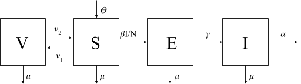

**Figure 1: SEIV model framework for canine rabies system in Arequipa**

In this model, the dog population is split into 4 compartments labeled “V”, “S”, “E”, and “I” corresponding to the following disease states: vaccinated, susceptible, exposed and infected. “N” is the total population (S+E+I+V) The arrows going between the compartments indicate flow of the population from one state to the other. For example, the arrow labeled “V1” indicates susceptibles moving from the susceptible compartment to the vaccinated compartment (by recieving the rabies vaccine). Different from classic SEIR models, there is no “R” or “recovered” population compartment because rabies is fatal once the dog is infected (World Health Organization, 2013). However, there is an effective rabies vaccine which confers immunity, so the “recovered” compartment is replaced with a “vaccinated” compartment. Parameters will be explained and calculated in full detail below.

From the model framework, we can write a system of ordinary differential equations describing the flow of the population in and out of each compartment.

$dS/dt = \theta - \beta SI/N - \mu S - \nu_1 S + \nu_2 V$

$dE/dt = \beta SI/N - \gamma E -\mu E$

$dI/dt = \gamma E -\mu I - \alpha I$

$dV/dt = \nu_1 S - \nu_2 V - \mu V$

#### Parameters

The first step to simulating the rabies models is to define the parameters in the model framework (Figure 1). The rates of the population flow between compartments (defined by the parameters) are instantatneous and are equal to the inverse of the time spent in the compartments. We can use this relationship to calculate point estimates for the parameters.

*Known parameters*

```r
DOG_POPN= 203183 #Peru Ministry of Health estimate
GAMMA= 1/22.3 #Hampson 2009
NU2 = 1/365 #vaccine label
ETA = 0 #initial vaccination coverage, setting to 0 for simplicity and will have first vancan on day 1
```

After known parameters are collected, unknown parameters are estimated based on the data from Arequipa.

*$\mu$ (background death rate)*

$\mu$ is the instantaneous per capita death rate of dogs not attributable to rabies. It can be estimated as the inverse of average age of dogs.

```r
df_2019 <- df_2019 %>%
  mutate(Age = Years*365.25 + Months*30.4375)
#MU <- 1/t.test(df_2019$Age)$estimate[[1]] #Mean: 1099.203 [1063.346, 1135.060]
MU <- 1/1099.203
```

*$\alpha$ (rabies death rate)* $\alpha$ is the instantaneous per capita death rate of rabid dogs and can be calculated as the inverse of the time spent in the infectious compartment (1/infectious period).

```r
df$Infectious <- df$Death_date - df$Symptoms_date
#ALPHA <- 1/t.test(df$Infectious)$estimate[[1]] #2.534247 [1.931721, 3.136772]
ALPHA <- 1/2.534247
```

*$\nu_1$ (vaccination coverage)*

$\nu_1$ is the instantaneous rate of immunity from vaccination. From our data we can calculate the coverage rates of dogs per year, and the day in which the majority of the vaccinations occured. Additionally, based on pilot data shared from Sergio Recuenco we assume that 2014 and 2015 vaccine coverage was 48.98%. Finally we can transform coverage rates to instantaneous rates by using the equation: vaccination coverage = 1-e-v1*t, where t = 1 day.

```r
# #2016
# plyr::count(df_2016$Vaccine) #0.6147823
# plyr::count(df_2016$Date) #Mode= June 12
#
# #2017
# plyr::count(df_2017$Vaccine) #0.4989594
# plyr::count(df_2017$Date) #Mode= September 22
#
# #2018
# plyr::count(df_2018$Vaccine) #0.5285256
# plyr::count(df_2018$Date) #Mode= August 6
#
# #2019
# plyr::count(df_2019$Vaccine) #0.5850053
# plyr::count(df_2019$Date) #Mode= October 24

#Build table
NU1 <- data.frame(year=c(2014, 2015, 2016,2017,2018,2019),
                 date=as.Date(c("2014-06-12", "2015-06-12", "2016-06-12", "2017-09-22", "2018-08-06", "2019-10-02")),
                 vax=c(0.4898, 0.4898, 0.6148, 0.4990, 0.5285, 0.5850))

NU1$inst <- -log(1-NU1$vax)
```

*$R_{0}$ (basic reproductive number) and $\beta$ (transmission coefficient)*

$R_{0}$ is defined as the average number of secondary cases a primary case will infect in a totally susceptible population. An initial estimate of $R_{0}$ can be estimated by from survey data by the number of bites * the probabability of rabies transmission (Hampson, 2009). Using the estimate of rabies transmission probability from Hampson, 2009 (0.49), and the number of dogs a rabid dog bites from rabies case report data in Arequipa. We can calculate a rough estimate of $R_{0}$.

```r
#Extract bite data
bites <- as.vector(na.omit(df$NumDogsCaseBit))
bites <- as.data.frame(bites)
colnames(bites) <- c("counts")

unname((0.49*(t.test(bites$counts))$estimate[1]))
```

```
## [1] 1.366061
```

1.37 is a good starting estimate for $R_{0}$. However, not all bite events are observed by owners/ public health officials, so what is recorded in the data will be an underestimate of $R_{0}$. We can re-run the model increasing the model of R0 in small increments until we find the value of R0 that gives the lowest sum squared of residuals. Doing this, we find an increased value of 1.44.

```r
#fit to epidemic data by rerunning system in small increments and then calculate residuals
R_NAUGHT=1.44
```

$R_{0}$ is not used directly in the system of equations. However, it can be used to derive $\beta$. $\beta$ is the transmission coefficient and is used to describe the infection rate (which is also based on the prevalence of rabies).

Using next generation matrix techiques (Diekman, 2010), $\beta$ can be derived from the other parameters as: $\beta = R_{0} (\gamma + \mu) (\mu + \alpha)/\gamma$

#### Deterministic Model

With all parameters calculated, we can formulate the deterministic SEIV model so that R can solve it.

First we save all parameters in a column that a can be inputted into a function.

```r
#Parameters
params <- c(R0= R_NAUGHT, #Bite: 1.366061, #Age:2.487201
            m = MU,#mu (normal death rate)
            g = GAMMA, #gamma (latency rate)
            a = ALPHA, #alpha (death rate attributable to rabies)
            u = NU2, #1 yr vaccine
            eta= ETA, #initial vaccine coverage --- (have vancan start at d1)
            N =DOG_POPN, #2645.503, #Do we want this to be density (per km2) or total
            #rho = RHO, #Reporting rate
            d2= 1) #delta2, density dependency weight [1 (freq), 0 (dens)]
params["d"] <- 1/params["N"] + params["d2"]*((params["N"]-1)/params["N"]) #model type weight: frequency vs density dependent
params["beta"] <-params["R0"]*params["d"]*(params["g"]+params["m"])*(params["a"]+params["m"])/params["g"]
```

We then set initial conditions. Our assumption is that rabies was reintroduced into Arequipa through the transport of a dog that was exposed to rabies but had not yet become symptomatic.

```r
#Initial conditions
init <- NULL # popn initial values
init["S"] <- (params["N"]-1)*(1-params["eta"])
init["E"] <- 1
init["I"] <- 0
init["R"] <- (params["N"]-1)*params["eta"]
init["H"] <- 0 #Accumulator variable
```

Because the vaccination campaign occured yearly we want to “pulse” vaccinations each year corresponding to the vaccination campaign. Here we set up the time dependent series of vaccination pulses.

```r
#Time dependent vaccination pulses for the yearly vaccination campaign
times <- seq(0, 2557, by = 1) #time series for model
signal <- data.frame(times = times, vax = rep(0, length(times))) #artificial time series

#specify vaccination coverage
signal$vax[1]    <- NU1$inst[1] #2014-03-16 ***Earliest year we have data from
signal$vax[366]  <- NU1$inst[2] #2015-03-16 ***Unreliable reports so using 2014 estimate
signal$vax[820]  <- NU1$inst[3] #2016-06-12
signal$vax[1287] <- NU1$inst[4] #2017-09-22
signal$vax[1605] <- NU1$inst[5] #2018-08-06
signal$vax[2049] <- NU1$inst[6] #2019-10-24

input <- approxfun(signal)#Interpolating fx
```

Next we can construct a function that encorporates the time series, the initial condition and the parameters into the system of equations derived for the model frame work.

```r
#deterministic model description
disease_dynamics <- function(times, state, params) {
  with(
    as.list(c(state, params)), {
      vax <- input(times)

      ##Equations (easy to read)
      dS <- (m*N + a*I) - beta*I*S/(d*N) - m*S -vax*S + u*R
      dE <- beta*S*I/(d*N) - g*E - m*E
      dI <- g*E -a*I - m*I
      dR <- vax*S - u*R - m*R
      dH <- beta*S*I/(d*N) #Acummulator variable- just a count of all cases moving into I
      return(list(c(dS, dE, dI, dR, dH), signal=vax))
    }
  )
}
```

Finally, we can use the deSolve package to solve the system of equations and get our results.

```r
#Run model
out <- as.data.frame(ode(y = init, times = times, func = disease_dynamics, parms = params))
RESULTS<-data.frame(out$S, out$E, out$I, out$R, out$H) #results
RESULTS$date <-seq(as.Date("2014/03/16"), as.Date("2021/03/16"), "days")

#Convert model results to accumulated incidence
RESULTS <- RESULTS %>%
  mutate(diffH = out.H - lag(out.H))
RESULTS$diffH[is.na(RESULTS$diffH)] <- 0 #set dates don't have date for as 0 (I.e beginning and end)
RESULTS$Date <- seq(as.Date("2014/03/16"), as.Date("2021/03/16"), "days") #Create ref of days
rabies.stim <- data.table::setDT(RESULTS)[, .(Incidence = sum(diffH)), by = .(yr = data.table::year(Date), mon = months(Date))] #count incidence by month
rabies$stim <- rabies.stim$Incidence #Match stim incidence with actual incidence df
rabies$stim_reports <- rabies$stim#*params["rho"] #scale down stim reports by reporting percent
```

#### Changes caused by COVID 19

Determinic models can be used to answer many crucial questions. For instance we can examine the effect of COVID-19 control measures instituded in Peru on rabies dynamics. In March, 2020, much like the rest of the world, Peru instituted lock down, quarantine and work from home measures that disrupted rabies control activities.

To do so, we can re-initialize the initial conditions based on those when COVID-19 restrictions were started.

```r
#Re initialize on March 16 (day of Peru lockdown)
init <- NULL # popn initial values
init["S"] <- RESULTS$out.S[RESULTS$Date == "2020-03-15"]
init["E"] <- RESULTS$out.E[RESULTS$Date == "2020-03-15"]
init["I"] <- RESULTS$out.I[RESULTS$Date == "2020-03-15"]
init["R"] <- RESULTS$out.R[RESULTS$Date == "2020-03-15"]
init["H"] <- RESULTS$out.H[RESULTS$Date == "2020-03-15"]
```

First we can examine the effect a cancelled (0% coverage) or reduced yearly mass vaccination campaign (58% coverage) versus an ideal coverage level (80%) on theoretical rabies cases over a year.

```r
#set up pulse vax for a year
times <- seq(0, 365, by = 1) #time series for model

#Ideal vaccination coverage scenario
signal <- data.frame(times = times, vax = rep(0, length(times)))
signal$vax[223] <- -log(1-0.8000) #2020-10-24  ---> 80% coverage
input <- approxfun(signal)
out <- as.data.frame(ode(y = init, times = times, func = disease_dynamics, parms = params)) #Fun model
RESULTS2<-data.frame(out$S, out$E, out$I, out$R, out$H) #format results
RESULTS2 <- RESULTS2 %>%
  mutate(diffH = out.H - lag(out.H))
RESULTS2$diffH[is.na(RESULTS2$diffH)] <- 0
RESULTS2$Date <- seq(as.Date("2020/03/16"), as.Date("2021/03/16"), "days") #create day ref


#Sub-optimal vaccination coverage scenario
signal <- data.frame(times = times, vax = rep(0, length(times)))
signal$vax[223] <- -log(1-0.5800) #2020-10-24 ---> 48% coverage
input <- approxfun(signal)
out <- as.data.frame(ode(y = init, times = times, func = disease_dynamics, parms = params)) #Fun model
RESULTS3<-data.frame(out$S, out$E, out$I, out$R, out$H) #format results
RESULTS3 <- RESULTS3 %>%
  mutate(diffH = out.H - lag(out.H))
RESULTS3$diffH[is.na(RESULTS3$diffH)] <- 0
RESULTS3$Date <- seq(as.Date("2020/03/16"), as.Date("2021/03/16"), "days") #create day ref

#Total cancellation of vaccination campaign
signal <- data.frame(times = times, vax = rep(0, length(times)))
signal$vax[223] <- -log(1-0.0000) #2020-10-24 ---> 0% coverage
input <- approxfun(signal)
out <- as.data.frame(ode(y = init, times = times, func = disease_dynamics, parms = params)) #Fun model
RESULTS4<-data.frame(out$S, out$E, out$I, out$R, out$H) #format results
RESULTS4 <- RESULTS4 %>%
  mutate(diffH = out.H - lag(out.H))
RESULTS4$diffH[is.na(RESULTS4$diffH)] <- 0
RESULTS4$Date <- seq(as.Date("2020/03/16"), as.Date("2021/03/16"), "days") #create day ref
```

Next, we can repeat these scenarios but with the added change of decreased surveillance. In Arequipa, public health officials respond to reports of rabid dogs and eliminate suspect cases, decreases the survival time of rabid dogs and affecting the parameter, $\alpha$. However, with COVID-19 restrictions, public health officials were not able to respond to reports of dogs acting rabies. This has the potential to increase the survival time of rabid dogs. Using the estimate of average length of survival of rabid dogs without intervention given by Hampson, 2009, we can set alpha to be the inverse of this estimate (3.7d) and re-run the simulation.

```r
#set alpha based on increasaed survival time or rabid dogs
params["a"] <- 1/3.7

##Rerun scenarios
#Ideal vaccination coverage scenario
signal <- data.frame(times = times, vax = rep(0, length(times)))
signal$vax[223] <- -log(1-0.8000) #2020-10-24  ---> 80% coverage
input <- approxfun(signal)
out <- as.data.frame(ode(y = init, times = times, func = disease_dynamics, parms = params)) #Fun model
RESULTS5<-data.frame(out$S, out$E, out$I, out$R, out$H) #format results
RESULTS5 <- RESULTS5 %>%
  mutate(diffH = out.H - lag(out.H))
RESULTS5$diffH[is.na(RESULTS5$diffH)] <- 0
RESULTS5$Date <- seq(as.Date("2020/03/16"), as.Date("2021/03/16"), "days") #create day ref


#Sub-optimal vaccination coverage scenario
signal <- data.frame(times = times, vax = rep(0, length(times)))
signal$vax[223] <- -log(1-0.5800) #2020-10-24 ---> 48% coverage
input <- approxfun(signal)
out <- as.data.frame(ode(y = init, times = times, func = disease_dynamics, parms = params)) #Fun model
RESULTS6<-data.frame(out$S, out$E, out$I, out$R, out$H) #format results
RESULTS6 <- RESULTS6 %>%
  mutate(diffH = out.H - lag(out.H))
RESULTS6$diffH[is.na(RESULTS6$diffH)] <- 0
RESULTS6$Date <- seq(as.Date("2020/03/16"), as.Date("2021/03/16"), "days") #create day ref

#Total cancellation of vaccination campaign
signal <- data.frame(times = times, vax = rep(0, length(times)))
signal$vax[223] <- -log(1-0.0000) #2020-10-24 ---> 0% coverage
input <- approxfun(signal)
out <- as.data.frame(ode(y = init, times = times, func = disease_dynamics, parms = params)) #Fun model
RESULTS7<-data.frame(out$S, out$E, out$I, out$R, out$H) #format results
RESULTS7 <- RESULTS7 %>%
  mutate(diffH = out.H - lag(out.H))
RESULTS7$diffH[is.na(RESULTS7$diffH)] <- 0
RESULTS7$Date <- seq(as.Date("2020/03/16"), as.Date("2021/03/16"), "days") #create day ref
```

Next we can run simulations for 5 years to assess the relative impact of these disruptions. We will assume that the “normal” vaccination converage for Arequipa is 58% and that the normal survival time of rabid dogs (after symptom onset) is 2.5 days.

```r
##############################################################################################
#Scenario 0: No disruption (counterfactual)
##############################################################################################
#Set up time series params
times <- seq(0, 365*5+1, by = 1) #time series for model (5yrs)
params["a"] <- 1/2.5
signal <- data.frame(times = times, vax = rep(0, length(times)))
signal$vax[197]  <- -log(1-0.58) #2020-09-28  ---> 58% coverage
signal$vax[562]  <- -log(1-0.58) #2021-09-28  ---> 58% coverage
signal$vax[927]  <- -log(1-0.58) #2022-09-28  ---> 58% coverage
signal$vax[1292] <- -log(1-0.58) #2023-09-28  ---> 58% coverage
signal$vax[1658] <- -log(1-0.58) #2024-09-28  ---> 58% coverage
input <- approxfun(signal)

#Run model
out <- as.data.frame(ode(y = init, times = times, func = disease_dynamics, parms = params)) #Fun model
RESULTS.A<-data.frame(out$S, out$E, out$I, out$R, out$H) #format results
RESULTS.A <- RESULTS.A %>%
  mutate(diffH = out.H - lag(out.H))
RESULTS.A$diffH[is.na(RESULTS.A$diffH)] <- 0
RESULTS.A$Date<-seq(as.Date("2020/03/16"), as.Date("2025/03/16"), "days") #create day ref

##############################################################################################
#Scenario 3: 3 yr disruption(ST=3.7d, vax coverage = 12.3%)
##############################################################################################
#Part 1: disruption time period (1 yr)
times <- seq(0, 365*3, by = 1) #time series for model (3yr)
params["a"] <- 1/3.7 #Survival time increased
signal <- data.frame(times = times, vax = rep(0, length(times)))
signal$vax[197] <- -log(1-0.123) #2020-09-28  ---> 12.3% coverage
signal$vax[562] <- -log(1-0.123) #2021-09-28  ---> 12.3% coverage
signal$vax[927] <- -log(1-0.123) #2022-09-28  ---> 12.3% coverage
input <- approxfun(signal)
out <- as.data.frame(ode(y = init, times = times, func = disease_dynamics, parms = params)) #Fun model
RESULTS.B<-data.frame(out$S, out$E, out$I, out$R, out$H) #format results
RESULTS.B <- RESULTS.B %>%
  mutate(diffH = out.H - lag(out.H))
RESULTS.B$diffH[is.na(RESULTS.B$diffH)] <- 0
RESULTS.B$Date <- seq(as.Date("2020/03/16"), as.Date("2023/03/16"), "days") #create day ref

#Part 2: Normal control activities resume
init3 <- NULL # popn initial values
init3["S"] <- RESULTS.B$out.S[RESULTS.B$Date == "2023-03-15"]
init3["E"] <- RESULTS.B$out.E[RESULTS.B$Date == "2023-03-15"]
init3["I"] <- RESULTS.B$out.I[RESULTS.B$Date == "2023-03-15"]
init3["R"] <- RESULTS.B$out.R[RESULTS.B$Date == "2023-03-15"]
init3["H"] <- RESULTS.B$out.H[RESULTS.B$Date == "2023-03-15"]

times <- seq(0, 365*2+1, by = 1) #time series for model (5-3yr)
params["a"] <- 1/2.5 #Survival time increased
signal <- data.frame(times = times, vax = rep(0, length(times)))
signal$vax[197] <- -log(1-0.58) #2023-09-28  ---> 58% coverage
signal$vax[563] <- -log(1-0.58) #2024-09-28  ---> 58% coverage
input <- approxfun(signal)
out <- as.data.frame(ode(y = init3, times = times, func = disease_dynamics, parms = params)) #Fun model
RESULTS.B2<-data.frame(out$S, out$E, out$I, out$R, out$H) #format results
RESULTS.B2 <- RESULTS.B2 %>%
  mutate(diffH = out.H - lag(out.H))
RESULTS.B2$diffH[is.na(RESULTS.B2$diffH)] <- 0
RESULTS.B2$Date <- seq(as.Date("2023/03/15"), as.Date("2025/03/15"), "days") #create day ref

RESULTS.B1 <- RESULTS.B %>%
  filter(Date < as.Date("2023-03-15"))

RESULTS.B <- rbind(RESULTS.B1, RESULTS.B2)

##############################################################################################
#Scenario 2: 2 yr disruption(ST=3.7d, vax coverage = 12.3%)
##############################################################################################

#Part 2: Normal control activities resume
init2 <- NULL # popn initial values
init2["S"] <- RESULTS.B$out.S[RESULTS.B$Date == "2022-03-15"]
init2["E"] <- RESULTS.B$out.E[RESULTS.B$Date == "2022-03-15"]
init2["I"] <- RESULTS.B$out.I[RESULTS.B$Date == "2022-03-15"]
init2["R"] <- RESULTS.B$out.R[RESULTS.B$Date == "2022-03-15"]
init2["H"] <- RESULTS.B$out.H[RESULTS.B$Date == "2022-03-15"]

times <- seq(0, 365*3+1, by = 1) #time series for model
params["a"] <- 1/2.5 #Survival time increased
signal <- data.frame(times = times, vax = rep(0, length(times)))
signal$vax[197] <- -log(1-0.58) #2022-09-28  ---> 58% coverage
signal$vax[562] <- -log(1-0.58) #2023-09-28  ---> 58% coverage
signal$vax[928] <- -log(1-0.58) #2024-09-28  ---> 58% coverage

input <- approxfun(signal)
out <- as.data.frame(ode(y = init2, times = times, func = disease_dynamics, parms = params)) #Fun model
RESULTS.C2<-data.frame(out$S, out$E, out$I, out$R, out$H) #format results
RESULTS.C2 <- RESULTS.C2 %>%
  mutate(diffH = out.H - lag(out.H))
RESULTS.C2$diffH[is.na(RESULTS.C2$diffH)] <- 0
RESULTS.C2$Date <- seq(as.Date("2022/03/15"), as.Date("2025/03/15"), "days") #create day ref

RESULTS.C1 <- RESULTS.B %>%
  filter(Date < as.Date("2022-03-15"))

RESULTS.C <- rbind(RESULTS.C1, RESULTS.C2)
##############################################################################################
#Scenario 1: 1 yr disruption(ST=3.7d, vax coverage = 12.3%)
##############################################################################################

#Part 2: Normal control activities resume
init1 <- NULL # popn initial values
init1["S"] <- RESULTS.B$out.S[RESULTS.B$Date == "2021-03-15"]
init1["E"] <- RESULTS.B$out.E[RESULTS.B$Date == "2021-03-15"]
init1["I"] <- RESULTS.B$out.I[RESULTS.B$Date == "2021-03-15"]
init1["R"] <- RESULTS.B$out.R[RESULTS.B$Date == "2021-03-15"]
init1["H"] <- RESULTS.B$out.H[RESULTS.B$Date == "2021-03-15"]

times <- seq(0, 365*4+1, by = 1) #time series for model
params["a"] <- 1/2.5 #Survival time increased
signal <- data.frame(times = times, vax = rep(0, length(times)))
signal$vax[197]  <- -log(1-0.58) #2021-09-28  ---> 58% coverage
signal$vax[562]  <- -log(1-0.58) #2022-09-28  ---> 58% coverage
signal$vax[927]  <- -log(1-0.58) #2023-09-28  ---> 58% coverage
signal$vax[1293] <- -log(1-0.58) #2024-09-28  ---> 58% coverage
input <- approxfun(signal)

out <- as.data.frame(ode(y = init1, times = times, func = disease_dynamics, parms = params)) #Fun model
RESULTS.D2<-data.frame(out$S, out$E, out$I, out$R, out$H) #format results
RESULTS.D2 <- RESULTS.D2 %>%
  mutate(diffH = out.H - lag(out.H))
RESULTS.D2$diffH[is.na(RESULTS.D2$diffH)] <- 0
RESULTS.D2$Date <- seq(as.Date("2021/03/15"), as.Date("2025/03/15"), "days") #create day ref

RESULTS.D1 <- RESULTS.B %>%
  filter(Date < as.Date("2021-03-15"))

RESULTS.D <- rbind(RESULTS.D1, RESULTS.D2)
```

## Results

#### Epidemiologic data exploration

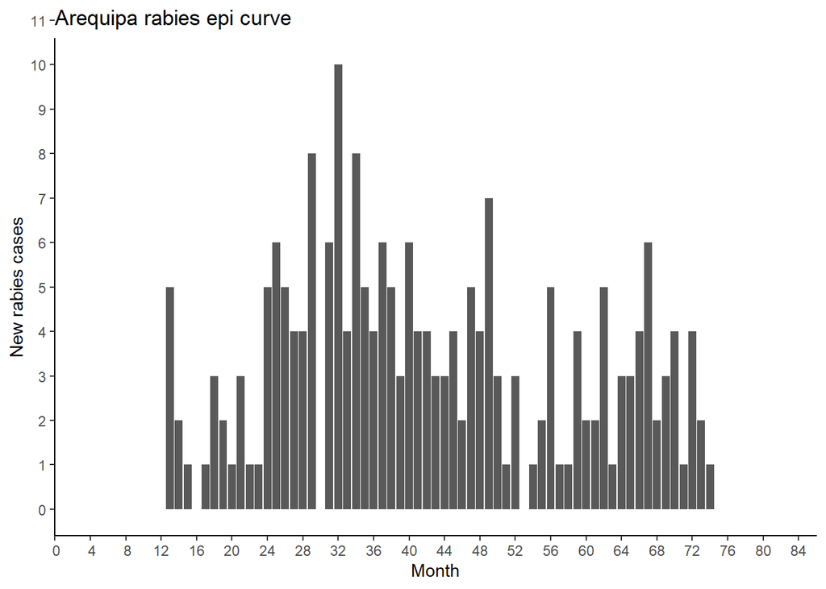

```r
#Epi curve
fig2 <- ggplot() +
  theme_classic()+
  geom_col(data = rabies, aes(x=month, y=reports))+
  scale_x_discrete(breaks=seq(0, max(rabies$month)+1, 1),
                   limits=seq(0, max(rabies$month)+1, 4))+
  scale_y_discrete(breaks=seq(0, max(rabies$reports)+1, 1),
                   limits=seq(0, max(rabies$reports)+1, 1))+
  xlab("Month") + ylab("New rabies cases")+
  ggtitle("Arequipa rabies epi curve")
fig2
```

**Figure 2: Epidemiologic curve of reported canine rabies incidence**

```r
params.table <- data.frame(
  Parameter= c("$\\theta$", "$\\beta$", "$\\mu$", "$\\gamma$", "$\\alpha$", "$\\nu_2$"),
  Estimate= c("mu*N + a*I", unname(params["beta"]), MU, GAMMA, ALPHA, NU2))

params.table %>%
  kableExtra::kbl(caption = "Table 1: Estimated parameters")%>%
  kableExtra::kable_styling()
```

Table 1: Estimated parameters

| Parameter | Estimate |
| --- | --- |
| $\theta$ | mu*N + a*I |
| $\beta$ | 0.581080381190508 |
| $\mu$ | 0.000909750064364817 |
| $\gamma$ | 0.0448430493273543 |
| $\alpha$ | 0.394594528473349 |
| $\nu_2$ | 0.00273972602739726 |

```r
NU1 %>%
  rename(Year = year, Date=date, Coverage=vax, Rate=inst)%>%
  kableExtra::kbl(caption = "Table 2: Estimated vaccination rates per year")%>%
  kableExtra::kable_styling()
```

Table 2: Estimated vaccination rates per year

| Year | Date | Coverage | Rate |
| --- | --- | --- | --- |
| 2014 | 2014-06-12 | 0.4898 | 0.6729525 |
| 2015 | 2015-06-12 | 0.4898 | 0.6729525 |
| 2016 | 2016-06-12 | 0.6148 | 0.9539926 |
| 2017 | 2017-09-22 | 0.4990 | 0.6911492 |
| 2018 | 2018-08-06 | 0.5285 | 0.7518362 |
| 2019 | 2019-10-02 | 0.5850 | 0.8794768 |

#### Deterministic model results

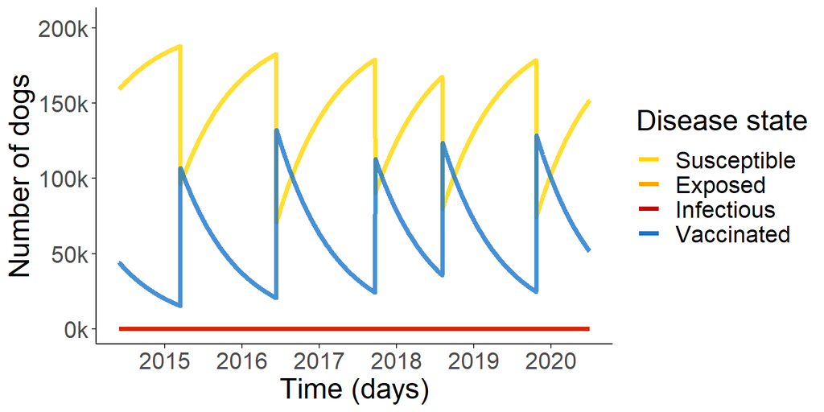

```r
#plot whole system dynamics
Pal1 <- c('Susceptible' = 'gold',
  'Exposed' = 'orange1',
  'Infectious' = 'red3',
  'Vaccinated' = 'dodgerblue3')

fig4 <- ggplot()+
  theme_classic()+ #white background w/ out grid
  geom_line(data=RESULTS, aes(x=date, y=out.S, color="Susceptible"), size=1.5, alpha=0.8)+
  geom_line(data=RESULTS, aes(x=date, y=out.E, color="Exposed"), size=1.5, alpha=0.8)+
  geom_line(data=RESULTS, aes(x=date, y=out.I, color="Infectious"), size=1.5, alpha=0.8)+
  geom_line(data=RESULTS, aes(x=date, y=out.R, color="Vaccinated"), size =1.5, alpha=0.8)+
   scale_y_continuous(labels = function(l) {
     trans = l / 1000
     paste0(trans, "k")
     })+
#  ggtitle("Deterministic model") + #title label
  scale_color_manual(values = Pal1, name= "Disease state", breaks=c("Susceptible","Exposed","Infectious","Vaccinated")) +
    scale_x_date(date_breaks= "1 year", date_labels="%Y", limits=c(as.Date("2014-06-01", "%Y-%m-%d"), as.Date("2020-07-01", "%Y-%m-%d")))+
  theme(text = element_text(size=20),
        axis.text.x = element_text(size=16))+
  labs(y= "Number of dogs", x = "Time (days)") #axis labels
fig4
```

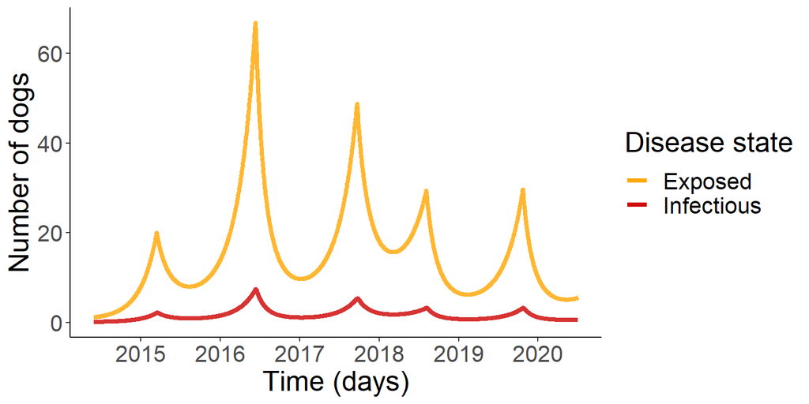

```r
fig4b <- ggplot()+
  theme_classic()+ #white background w/ out grid
 # geom_line(data=RESULTS, aes(x=date, y=out.S, color="Susceptible"), size=1.5, alpha=0.8)+
  geom_line(data=RESULTS, aes(x=date, y=out.E, color="Exposed"), size=1.5, alpha=0.8)+
  geom_line(data=RESULTS, aes(x=date, y=out.I, color="Infectious"), size=1.5, alpha=0.8)+
  #geom_line(data=RESULTS, aes(x=date, y=out.R, color="Vaccinated"), size =1.5, alpha=0.8)+
#  ggtitle("Deterministic model") + #title label
  scale_color_manual(values = Pal1, name= "Disease state", breaks=c("Susceptible","Exposed","Infectious","Vaccinated")) +
    scale_x_date(date_breaks= "1 year", date_labels="%Y", limits=c(as.Date("2014-06-01", "%Y-%m-%d"), as.Date("2020-07-01", "%Y-%m-%d")))+
  theme(text = element_text(size=20),
        axis.text.x = element_text(size=16))+
  labs(y= "Number of dogs", x = "Time (days)") #axis labels
fig4b
```

**Figure 4: Simulated population dynamics from deterministic rabies model**

When comparing reported cases to simulated cases assuming a 10% reporting rate, the fit seems reasonable (Figure 5). Variations can be explained by uncertainty with case reporting: rabies woldwide is underreported, especially in dogs (World Health Organization, 2013), and by population heterogeneity.

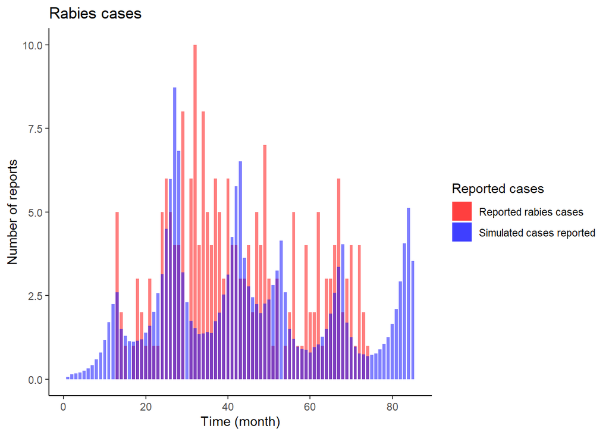

```r
#Plot of incidence real vs stim
fig5 <- ggplot()+
  theme_classic()+ #white background w/ out grid
  geom_col(data = rabies, aes(x=month, y=reports, fill="Reported rabies cases", alpha="Reported rabies cases"), width=0.75)+
  geom_col(data = rabies, aes(x=month, y=.1*stim_reports, fill="Simulated cases reported", alpha="Simulated cases reported"),  width= 0.75)+
  ggtitle("Rabies cases") + #title label
  #scale_x_date(date_breaks= "2 months", date_labels="%Y", limits=c(as.Date("2014-03-16", "%Y"), as.Date("2020", "%Y")))+
  scale_fill_manual(values = c(
      'Reported rabies cases' = 'red',
      'Simulated cases reported' = 'blue'),
       name= "Reported cases") +
  scale_alpha_manual(values = c(
    'Reported rabies cases' = 0.5,
    'Simulated cases reported' = 0.5),
    name= "Reported cases") +
  labs(y= "Number of reports", x = "Time (month)") #axis labels
fig5
```

**Figure 5: Observed versus simulated rabies case incidence**

#### COVID 19 changes

Due to restrictions instituted in Peru to control SARS-CoV-2 spread, there has been decreased vaccination and delayed vaccination campaigns. When investigating scenarios of how these measures effect rabies dynamics, we see a range of possibilities over a year depending on the scenario (Figure 6). When control activities are able to maintain the normal survival time (ST) of rabid dogs at 2.5 days, there are less overall cases than an increased ST of 3.7 days (Figure 6). Similarly, the higher the level of vaccination coverage, the lower the overall rabies cases over the year. In the best case scenario where control activities maintain a normal ST and vaccination coverage is optimal, canine rabies is nearly eliminated in a year (Figure 6), while in the worst case scenario with an increased ST and no vaccination coverage, rabies cases grow exponentially (Figure 6). Though it is now December and these predictions begin in March, there is still very little surveillance and subsequent case reports to be able to validate these predictions.

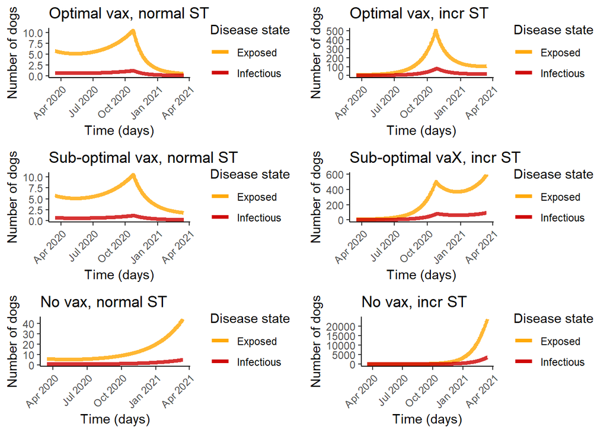

```r
#Plot
COVID_plots <- function(RESULTS, title) {
  p.sub <<- ggplot()+
    theme_classic()+ #white background w/ out grid
    geom_line(data=RESULTS, aes(x=Date, y=out.E, color="Exposed"), size=1.5, alpha=0.8)+
    geom_line(data=RESULTS, aes(x=Date, y=out.I, color="Infectious"), size=1.5, alpha=0.8)+
    ggtitle(title) + #title label
    theme(axis.text.x = element_text(angle = 45, hjust=1))+
    scale_color_manual(values = Pal1, name= "Disease state") +
    labs(y= "Number of dogs", x = "Time (days)") #axis labels
}

COVID_plots(RESULTS2, "Optimal vax, normal ST"); C1 <- p.sub
COVID_plots(RESULTS3, "Sub-optimal vax, normal ST"); C2 <- p.sub
COVID_plots(RESULTS4, "No vax, normal ST"); C3 <- p.sub
COVID_plots(RESULTS5, "Optimal vax, incr ST"); C4 <- p.sub
COVID_plots(RESULTS6, "Sub-optimal vaX, incr ST"); C5 <- p.sub
COVID_plots(RESULTS7, "No vax, incr ST"); C6 <- p.sub

ggpubr::ggarrange(C1, C4, C2, C5, C3, C6, nrow = 3, ncol=2)
```

**Figure 6: Simulated rabies cases for different COVID scenarios**

To look at the intermediate term effects of COVID 19, we ran 5 year simulations for different scenarios:  
1. **Counterfactual- no disruptions**, maintained 2.5 day average survival time of rabid dogs and achieved yearly vaccination coverage of 58%  
2. **1 year disruption: From March 2020-March 2021**, survival time of rabid dogs increased to 3.7d and yearly vaccination campaign reached coverage of 12.3%, before returning to pre-pandemic normal (2.5 day average survival time of rabid dogs and achieved yearly vaccination coverage of 58%)  
3. **2 year disruption: From March 2020-March 2022**, survival time of rabid dogs increased to 3.7d and yearly vaccination campaign reached coverage of 12.3%, before returning to pre-pandemic normal (2.5 day average survival time of rabid dogs and achieved yearly vaccination coverage of 58%)  
4. **3 year disruption: From March 2020-March 2023**, survival time of rabid dogs increased to 3.7d and yearly vaccination campaign reached coverage of 12.3%, before returning to pre-pandemic normal (2.5 day average survival time of rabid dogs and achieved yearly vaccination coverage of 58%)

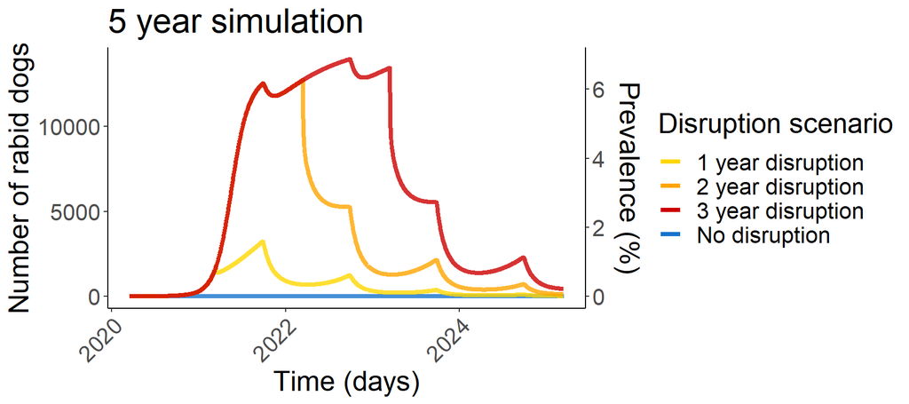

```r
Pal2 <- c('1 year disruption' = 'gold',
          '2 year disruption' = 'orange1',
          '3 year disruption' = 'red3',
          'No disruption' = 'dodgerblue3')
fig6 <- ggplot()+
    theme_classic()+ #white background w/ out grid
    geom_line(data=RESULTS.A, aes(x=Date, y=out.I, color="No disruption"), size=1.5, alpha=0.8)+
    geom_line(data=RESULTS.D, aes(x=Date, y=out.I, color="1 year disruption"), size=1.5, alpha=0.8)+
    geom_line(data=RESULTS.C, aes(x=Date, y=out.I, color="2 year disruption"), size=1.5, alpha=0.8)+
    geom_line(data=RESULTS.B, aes(x=Date, y=out.I, color="3 year disruption"), size=1.5, alpha=0.8)+
    ggtitle("5 year simulation") + #title label
    scale_color_manual(values = Pal2, name= "Disruption scenario") +
    scale_y_continuous(name="Number of rabid dogs",
                       sec.axis = sec_axis(trans=~.*100/params["N"], name="Prevalence (%)"))+
    theme(axis.text.x = element_text(angle = 45, hjust=1, size=16),
          text = element_text(size=20),
          axis.title.y.right = element_text(vjust=2))+
    labs(x = "Time (days)") #axis labels

fig6
```

## References

Castillo-Neyra, R., Toledo, A. M., Arevalo-Nieto, C., MacDonald, H., Puente-León, M. D. la, Naquira-Velarde, C., Paz-Soldan, V. A., Buttenheim, A. M., & Levy, M. Z. (2019). Socio-spatial heterogeneity in participation in mass dog rabies vaccination campaigns, Arequipa, Peru. PLOS Neglected Tropical Diseases, 13(8), e0007600. https://doi.org/10.1371/journal.pntd.0007600

Diekmann, O., Heesterbeek, J. A. P., & Roberts, M. G. (2010). The construction of next-generation matrices for compartmental epidemic models. Journal of the Royal Society Interface, 7(47), 873–885. https://doi.org/10.1098/rsif.2009.0386

Hampson, K., Dushoff, J., Cleaveland, S., Haydon, D. T., Kaare, M., Packer, C., & Dobson, A. (2009). Transmission Dynamics and Prospects for the Elimination of Canine Rabies. PLOS Biology, 7(3), e1000053. https://doi.org/10.1371/journal.pbio.1000053

Institute for Disease Modelling. (2020). SEIR and SEIRS models. https://docs.idmod.org/projects/emod-hiv/en/latest/model-seir.html

King, A. (2017). Exact simulation of birth-death processes via the Gillespie algorithm. https://kingaa.github.io/clim-dis/stochsim/gillespie.html

Red Arequipa Caylloma. (2019). Plan de accion de la campaña de vacunacion antirabica canina 2019. https://redperifericaaqp.gob.pe/wp-content/uploads/2019/04/accion-de-la-campana-atirabica-2019-comprimido.pdf

World Health Organization. (2013). WHO Expert Consultation on Rabies: Second report. World Health Organization. https://apps.who.int/iris/handle/10665/85346